# Quality control using Xbar and S charts

Xiaocui Zhang 16142030

### 1 About the data

The file monitor.csv contains comma separated data. The columns are:  
1. Timestamp - the timestamp of a model prediction being run  
2. ProcessMemory - the allocated memory (MB) of the relevant server process  
3. Prediction - the value predicted by the model  
4. PredictionTimeMS - the duration of the prediction task in milliseconds

### 2 Data loading

```r
library(readr)
monitor.df <- read.csv("D:\\Applied data science\\423\\Assignmnet4\\monitor.csv",header = TRUE)
```

### 3 Data processing

```r
str(monitor.df)
```

```
'data.frame':   10000 obs. of  4 variables:
 $ Timestamp       : Factor w/ 9990 levels "2019-01-01 13:14:17",..: 1 2 3 4 5 6 7 8 9 10 ...
 $ ProcessMemory   : num  12.4 12.1 12.5 12.6 11.3 ...
 $ Prediction      : num  42.2 57 66.1 58.4 43.2 ...
 $ PredictionTimeMS: num  232 433 357 303 252 ...
```

There are 10000 observations of 4 variables in the data set.As the Timestamp variable is a factor,we could convert it to DateTime and extract the date for aggregation.

```r
library(base)
library(dplyr)
monitor.df$Timestamp =as.POSIXct(as.character(monitor.df$Timestamp),format="%Y-%m-%d %H:%M:%S")
monitor.df=monitor.df%>% mutate(Date =as.Date(Timestamp))

monitor.df
```

| Timestamp | ProcessMemory | Prediction | PredictionTimeMS | Date |
| --- | --- | --- | --- | --- |
| 2019-01-01 13:14:17 | 12.39388 | 42.15490 | 231.7901 | 2019-01-01 |
| 2019-01-01 13:30:41 | 12.14166 | 57.01404 | 433.0228 | 2019-01-01 |
| 2019-01-01 13:49:26 | 12.53971 | 66.14251 | 357.3849 | 2019-01-01 |
| 2019-01-01 14:29:09 | 12.60013 | 58.44801 | 302.7545 | 2019-01-01 |
| 2019-01-01 14:53:16 | 11.26018 | 43.16347 | 251.9709 | 2019-01-01 |
| 2019-01-01 15:35:55 | 11.68703 | 56.06360 | 474.8445 | 2019-01-01 |
| 2019-01-01 16:18:49 | 11.70371 | 44.03377 | 368.7641 | 2019-01-01 |
| 2019-01-01 16:30:09 | 11.09502 | 51.30714 | 300.6655 | 2019-01-01 |
| 2019-01-01 16:50:29 | 11.87291 | 66.08439 | 140.0332 | 2019-01-01 |
| 2019-01-01 17:01:43 | 12.44097 | 50.50009 | 311.1654 | 2019-01-01 |

[output cut: 990 more lines]

```r
# result<-monitor.df%>%
#     group_by(Date)%>%
#     summarise(Memory_day=sum(ProcessMemory),Duration_day =sum(PredictionTimeMS), Predictedvalue_day =sum(Prediction))%>%
#     arrange(Date)
```

### 4 Control charts generation

#### a) Is the memory usage of the server in control?

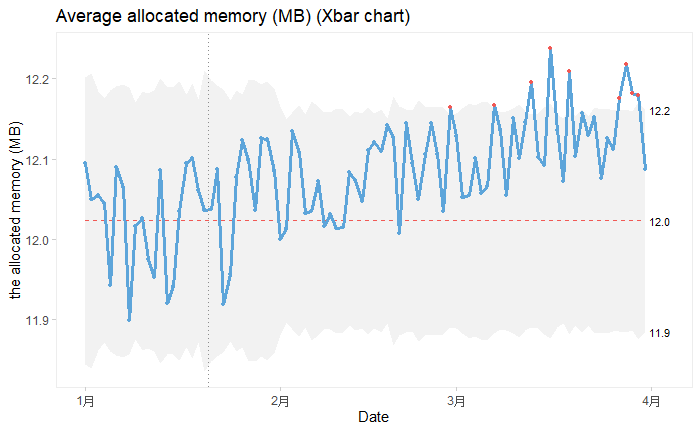

```r
library(qicharts2)
pxbar_memory <- qicharts2::qic(x = Date, y = ProcessMemory, data = monitor.df, chart = "xbar", freeze = 20,  title   = 'Average allocated memory (MB) (Xbar chart)',
                               ylab = 'the allocated memory (MB)',xlab = 'Date')
#Assume the first 20 days of data can be used to establish the control limits for the remainder of the data  => freeze = 20

plot(pxbar_memory)
```

```r
summary(pxbar_memory)
```

|  | facet1 | facet2 | part | n.obs | n.useful | longest.run | longest.run.max | n.crossings | n.crossings.min | runs.signal | aLCL | CL | aUCL | sigma.signal |
| --- | --- | --- | --- | --- | --- | --- | --- | --- | --- | --- | --- | --- | --- | --- |
| 1 | 1 | 1 | 1 | 90 | 90 | 39 | 9 | 18 | 37 | 1 | 11.87401 | 12.02266 | 12.17132 | 9 |

According to the Xbar chart and the summary, there are 9 breaches(red points) of the upper and lower control limits as sigma.signal=9. The limit rule has been breached.  
The runs.signal is 1 because longest.run (39)> longest.run.max(9) or n.crossings(18)<n.crossings.min(37), which indicates the runs rule and crossing rule have been breached.  
The memory usage of the server is not “in-control” with respect to the Xbar chart.

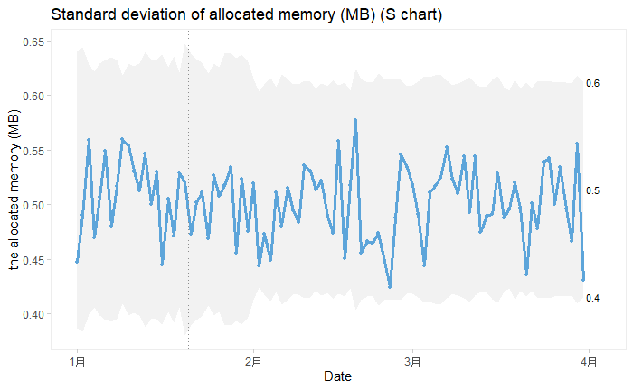

```r
ps_memory <- qicharts2::qic(x = Date, y = ProcessMemory, data = monitor.df, chart = "s", freeze = 20,  title   = 'Standard deviation of allocated memory (MB) (S chart)',
                             ylab = 'the allocated memory (MB)',xlab = 'Date')
plot(ps_memory)
```

```r
summary(ps_memory)
```

|  | facet1 | facet2 | part | n.obs | n.useful | longest.run | longest.run.max | n.crossings | n.crossings.min | runs.signal | aLCL | CL | aUCL | sigma.signal |
| --- | --- | --- | --- | --- | --- | --- | --- | --- | --- | --- | --- | --- | --- | --- |
| 1 | 1 | 1 | 1 | 90 | 90 | 7 | 9 | 48 | 37 | 0 | 0.4084183 | 0.5139113 | 0.6194042 | 0 |

According to the S chart and the summary, there is no breaches(red points).The sigma.signal is 0 and runs.signal is 0,which indicates no rules are breached.  
The memory usage of the server is “in-control” with respect to the S chart.

**Since the Xbar chart is out of control, we conclude that the memory usage of the server overall is out of control.**

#### b) Is the prediction time of the model in control?

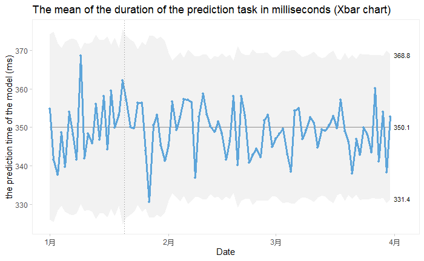

```r
pxbar_predictiontime <- qicharts2::qic(x = Date, y = PredictionTimeMS, data = monitor.df, chart = "xbar", freeze = 20,  title   = 'The mean of the duration of the prediction task in milliseconds (Xbar chart)',ylab = 'the prediction time of the model (ms)',xlab = 'Date')
plot(pxbar_predictiontime)
```

```r
summary(pxbar_predictiontime)
```

|  | facet1 | facet2 | part | n.obs | n.useful | longest.run | longest.run.max | n.crossings | n.crossings.min | runs.signal | aLCL | CL | aUCL | sigma.signal |
| --- | --- | --- | --- | --- | --- | --- | --- | --- | --- | --- | --- | --- | --- | --- |
| 1 | 1 | 1 | 1 | 90 | 90 | 8 | 9 | 44 | 37 | 0 | 330.0784 | 350.1244 | 370.1705 | 0 |

According to the Xbar chart and the summary, there is no out-of-control points(red points).The sigma.signal is 0 and runs.signal is 0,which indicates no rules are breached.  
The prediction time of the model is “in-control” with respect to the Xbar chart.

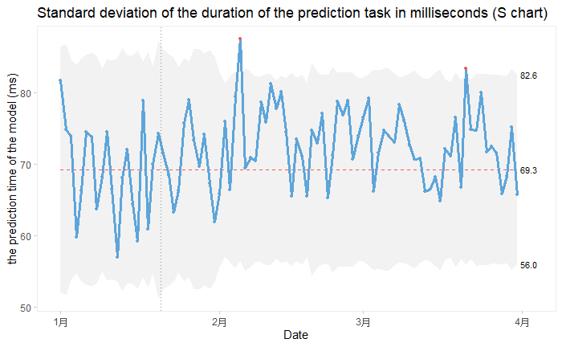

```r
ps_predictiontime <- qicharts2::qic(x = Date, y = PredictionTimeMS, data = monitor.df, chart = "s", freeze = 20,  title   = 'Standard deviation of the duration of the prediction task in milliseconds (S chart)',ylab = 'the prediction time of the model (ms)',xlab = 'Date')
plot(ps_predictiontime)
```

```r
summary(ps_predictiontime)
```

|  | facet1 | facet2 | part | n.obs | n.useful | longest.run | longest.run.max | n.crossings | n.crossings.min | runs.signal | aLCL | CL | aUCL | sigma.signal |
| --- | --- | --- | --- | --- | --- | --- | --- | --- | --- | --- | --- | --- | --- | --- |
| 1 | 1 | 1 | 1 | 90 | 90 | 11 | 9 | 31 | 37 | 1 | 55.07461 | 69.30017 | 83.52573 | 2 |

According to the S chart and the summary, there are 2 breaches(red points) of the upper and lower control limits as sigma.signal=2. The limit rule has been breached.  
The runs.signal is 1 because longest.run (11)> longest.run.max(9) or n.crossings(31)<n.crossings.min(37), which indicates the runs rule and crossing rule have been breached.  
The prediction time is out of control in terms of the s chart.

**As the S chart is out of control, the prediction time of the model is out of control in summary.**

#### c) Is the stream of predictions in control?

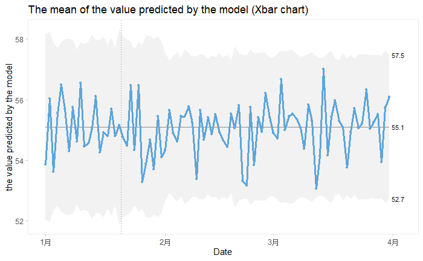

```r
pxbar_predictedValue <- qicharts2::qic(x = Date, y = Prediction, data = monitor.df, chart = "xbar", freeze = 20,  title   = 'The mean of the value predicted by the model (Xbar chart)',ylab = 'the value predicted by the model',xlab = 'Date')
plot(pxbar_predictedValue)
```

```r
summary(pxbar_predictedValue)
```

|  | facet1 | facet2 | part | n.obs | n.useful | longest.run | longest.run.max | n.crossings | n.crossings.min | runs.signal | aLCL | CL | aUCL | sigma.signal |
| --- | --- | --- | --- | --- | --- | --- | --- | --- | --- | --- | --- | --- | --- | --- |
| 1 | 1 | 1 | 1 | 90 | 90 | 4 | 9 | 57 | 37 | 0 | 52.55918 | 55.10462 | 57.65007 | 0 |

According to the Xbar chart and the summary, there is no out-of-control points.The sigma.signal is 0 and the runs.signal is 0,which indicates no rules are breached.  
The value predicted by the mode is in control according to the Xbar chart.

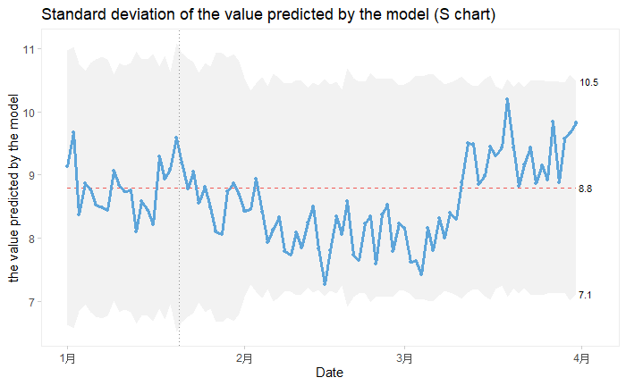

```r
ps_predictedValue <- qicharts2::qic(x = Date, y = Prediction, data = monitor.df, chart = "s", freeze = 20,  title   = 'Standard deviation of the value predicted by the model (S chart)',ylab = 'the value predicted by the model',xlab = 'Date')
plot(ps_predictedValue)
```

```r
summary(ps_predictedValue)
```

|  | facet1 | facet2 | part | n.obs | n.useful | longest.run | longest.run.max | n.crossings | n.crossings.min | runs.signal | aLCL | CL | aUCL | sigma.signal |
| --- | --- | --- | --- | --- | --- | --- | --- | --- | --- | --- | --- | --- | --- | --- |
| 1 | 1 | 1 | 1 | 90 | 90 | 35 | 9 | 16 | 37 | 1 | 6.993359 | 8.799718 | 10.60608 | 0 |

According to the S chart and the summary, there are no red points and the sigma.signal=0. The limit rule has not been breached.  
Howerver, the runs.signal is 1 because longest.run (35)> longest.run.max(9) or n.crossings(16)<n.crossings.min(37), which indicates the runs rule and crossing rule have been breached. There are 35 points that are consecutively below the middle line between Feb and the early March. The process Standard deviation was not in control during that time. And after then, the opints were consecutively above the middle line. The process is still not back in control.  
Hence,the stream of predictions is out of control based on the s chart.

**As the S chart is out of control, we conclude the stream of predictions overall is out of control.**

—————————————————————————————————- the end —————————————————————————-